# ETAPA 1 - Tratamento, Tipagem e EDA - `pedidos.csv` e `avaliacoes.csv`

## 3.5 EDA — O que cada score acrescenta ao BERTimbau?

Para entender se os scores de sentimento adicionam informação **além** do BERTimbau, calculamos a correlação de cada feature com o **resíduo do modelo BERTimbau puro**.

Se o score correlaciona com o resíduo, ele captura algo que o BERTimbau errou — feature útil. Se a correlação é próxima de zero, é redundante.

```python
# Split fixo — usado em todos os modelos
X_train_idx, X_test_idx, y_train, y_test = train_test_split(
    df.index, df['review_score'],
    test_size=TEST_SIZE, random_state=RANDOM_SEED, stratify=df['review_score']
)

# Treina BERTimbau + Ridge para obter resíduos
scaler_bert = StandardScaler()
X_tr_bert   = scaler_bert.fit_transform(X_embeddings[X_train_idx])
X_te_bert   = scaler_bert.transform(X_embeddings[X_test_idx])
m_bert_base = Ridge(alpha=1.0).fit(X_tr_bert, y_train)
p_bert_base = np.clip(m_bert_base.predict(X_te_bert), 1, 5)

residuos = y_test.values - p_bert_base

# Correlação de cada score de sentimento com os resíduos do BERTimbau
print('Correlação dos scores de sentimento com os RESÍDUOS do BERTimbau:')
print('(maior |correlação| = mais informação nova que o BERT não capturou)')
print('-' * 60)
corrs = {}
for feat in FEATS_SENT:
    vals  = df.loc[X_test_idx, feat].values
    corr  = np.corrcoef(vals, residuos)[0, 1]
    corrs[feat] = corr
    barra = '█' * int(abs(corr) * 200)
    print(f'  {feat:<22} {corr:+.4f}  {barra}')

melhor = max(corrs, key=lambda k: abs(corrs[k]))
print(f'\nFeature mais informativa (menor redundância): {melhor} ({corrs[melhor]:+.4f})')
```

```
Correlação dos scores de sentimento com os RESÍDUOS do BERTimbau:
(maior |correlação| = mais informação nova que o BERT não capturou)
------------------------------------------------------------
  vader_pos              -0.0015
  vader_neg              -0.0226  ████
  vader_neu              +0.0145  ██
  vader_compound         +0.0128  ██
  leia_pos               +0.0221  ████
  leia_neg               -0.0547  ██████████
  leia_neu               -0.0117  ██
  leia_compound          +0.0781  ███████████████
  tb_polarity            +0.0104  ██
  tb_subjectivity        +0.0048

Feature mais informativa (menor redundância): leia_compound (+0.0781)
```

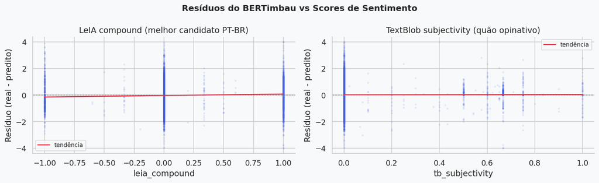

```
Se a linha de tendência for inclinada, o score captura algo além do BERTimbau.
```

```python
# Visualização: resíduo vs leia_compound e tb_subjectivity
fig, axes = plt.subplots(1, 2, figsize=(13, 4))
fig.suptitle('Resíduos do BERTimbau vs Scores de Sentimento',
             fontsize=13, fontweight='bold')

for ax, feat, titulo in zip(
    axes,
    ['leia_compound', 'tb_subjectivity'],
    ['LeIA compound (melhor candidato PT-BR)', 'TextBlob subjectivity (quão opinativo)']
):
    x = df.loc[X_test_idx, feat].values
    ax.scatter(x, residuos, alpha=0.08, s=5, color='#4361EE')
    # Linha de tendência
    z = np.polyfit(x, residuos, 1)
    p = np.poly1d(z)
    xs = np.linspace(x.min(), x.max(), 100)
    ax.plot(xs, p(xs), color='#EF233C', linewidth=1.5, label=f'tendência')
    ax.axhline(0, color='gray', linewidth=0.8, linestyle='--')
    ax.set_xlabel(feat); ax.set_ylabel('Resíduo (real - predito)')
    ax.set_title(titulo)
    ax.legend(fontsize=9)

plt.tight_layout()
plt.show()
print('Se a linha de tendência for inclinada, o score captura algo além do BERTimbau.')
```

Como interpretar esse gráfico O que estamos vendo: cada ponto é um comentário do conjunto de teste. O eixo X é o score de sentimento, o eixo Y é o erro que o BERTimbau cometeu (real − predito). A linha vermelha é a tendência.Se a linha fosse inclinada → o score de sentimento explica parte do erro do BERTimbau → feature útil.Se a linha for horizontal → o score não acrescenta nada além do que o BERTimbau já capturou.

## 3.6 Benchmark incremental

Adicionamos uma camada por vez e medimos o ganho marginal — permite identificar qual combinação compensa o custo de complexidade.

```python
from scipy.stats import pearsonr, spearmanr

# Pré-computa TF-IDF
STOPWORDS_PT = set([
    'de','a','o','que','e','do','da','em','um','para','com','uma','os','no',
    'se','na','por','mais','as','dos','como','mas','ao','ele','das','à','seu',
    'sua','ou','quando','muito','nos','já','eu','também','só','pelo','pela',
    'até','isso','ela','entre','depois','sem','mesmo','aos','seus','quem','nas',
    'me','esse','eles','você','essa','num','nem','suas','meu','às','minha',
    'numa','pelos','elas','seja','qual','será','nós','tenho','lhe','deles',
    'essas','esses','pelas','este','foi','ter','tem','temos','foram','está',
    'tinha','estou','vou','vai','fui','era','ser','não','sim','aqui','ali',
    'lá','então','agora','ainda','aquele','tudo','todo','todos','toda','todas',
    'cada','outro','outra','outros','outras','nada','algo','alguém','ninguém',
    'algum','alguma','alguns','algumas','nenhum','nenhuma','há','la','le','pra',
    'pro','bem','ta','tá','tb','tbm','faz','fazer','feito','ficou','ficei',
    'fique','fica','veio','vem','vir','vão','vim','ver','vi','vejo',
    'so','ja','ne','né','nao','ai','aí','ah','oh','oi','ola',
])

def clean_text(t):
    if not isinstance(t, str): return ''
    t = t.lower()
    t = re.sub(r'[^a-záàâãéèêíïóôõöúüçñ\s]', ' ', t)
    t = re.sub(r'\s+', ' ', t).strip()
    return ' '.join([w for w in t.split() if w not in STOPWORDS_PT and len(w) > 2])

df['text_clean'] = df['texto'].apply(clean_text)
tfidf = TfidfVectorizer(max_features=8000, ngram_range=(1,2),
                        min_df=20, sublinear_tf=True, strip_accents='unicode')
X_tr_tfidf = tfidf.fit_transform(df.loc[X_train_idx, 'text_clean'])
X_te_tfidf = tfidf.transform(df.loc[X_test_idx, 'text_clean'])

# Pré-escala sentimento
scaler_sent = StandardScaler()
X_tr_sent = csr_matrix(scaler_sent.fit_transform(df.loc[X_train_idx, FEATS_SENT]))
X_te_sent = csr_matrix(scaler_sent.transform(df.loc[X_test_idx, FEATS_SENT]))

# ── Função avaliar atualizada ────────────────────────────────────────────────
def avaliar(nome, X_tr, X_te):
    m = Ridge(alpha=1.0).fit(X_tr, y_train)
    p = np.clip(m.predict(X_te), 1, 5)
    pr, _ = pearsonr(y_test, p)
    sr, _ = spearmanr(y_test, p)
    return {
        'nome'    : nome,
        'modelo'  : m,
        'preds'   : p,
        'pearson' : pr,
        'spearman': sr,
        'rmse'    : np.sqrt(mean_squared_error(y_test, p)),
        'mae'     : mean_absolute_error(y_test, p),
        'acc1'    : (np.abs(np.round(p) - y_test.values) <= 1).mean(),
        'n_feats' : X_tr.shape[1]
    }

print('Rodando benchmark incremental...')
print(f'{"Modelo":<40} {"Pearson":>9} {"Spearman":>10} {"RMSE":>8} {"MAE":>8} {"Ac.±1":>8} {"Features":>10}')
print('-' * 100)

resultados = []

configs = [
    ('TF-IDF',                   hstack([X_tr_tfidf]),                        hstack([X_te_tfidf])),
    ('BERTimbau',                csr_matrix(X_tr_bert),                        csr_matrix(X_te_bert)),
    ('BERT + TF-IDF',            hstack([csr_matrix(X_tr_bert), X_tr_tfidf]), hstack([csr_matrix(X_te_bert), X_te_tfidf])),
    ('BERT + TF-IDF + VADER',    hstack([csr_matrix(X_tr_bert), X_tr_tfidf,
                                         csr_matrix(scaler_sent.fit_transform(df.loc[X_train_idx, FEATS_VADER]))]),
                                 hstack([csr_matrix(X_te_bert), X_te_tfidf,
                                         csr_matrix(scaler_sent.transform(df.loc[X_test_idx, FEATS_VADER]))])),
    ('BERT + TF-IDF + LeIA',     hstack([csr_matrix(X_tr_bert), X_tr_tfidf,
                                         csr_matrix(scaler_sent.fit_transform(df.loc[X_train_idx, FEATS_LEIA]))]),
                                 hstack([csr_matrix(X_te_bert), X_te_tfidf,
                                         csr_matrix(scaler_sent.transform(df.loc[X_test_idx, FEATS_LEIA]))])),
    ('BERT + TF-IDF + TextBlob', hstack([csr_matrix(X_tr_bert), X_tr_tfidf,
                                         csr_matrix(scaler_sent.fit_transform(df.loc[X_train_idx, FEATS_TB]))]),
                                 hstack([csr_matrix(X_te_bert), X_te_tfidf,
                                         csr_matrix(scaler_sent.transform(df.loc[X_test_idx, FEATS_TB]))])),
    ('BERT + TF-IDF + Todos',    hstack([csr_matrix(X_tr_bert), X_tr_tfidf, X_tr_sent]),
                                 hstack([csr_matrix(X_te_bert), X_te_tfidf, X_te_sent])),
]

pearson_ref = None
for nome, X_tr, X_te in configs:
    r = avaliar(nome, X_tr, X_te)
    resultados.append(r)
    if pearson_ref is None: pearson_ref = r['pearson']
    flag = ' ← melhor até aqui' if r['pearson'] == max(x['pearson'] for x in resultados) else ''
    print(f'  {nome:<38} {r["pearson"]:>9.4f} {r["spearman"]:>10.4f} '
          f'{r["rmse"]:>8.4f} {r["mae"]:>8.4f} {r["acc1"]:>8.2%} {r["n_feats"]:>10,}{flag}')

# Adiciona Ridge + TF-IDF da Etapa 2 para comparação
resultados.append({
    'nome'    : 'Ridge + TF-IDF (Etapa 2)',
    'preds'   : preds_clipped,
    'pearson' : pearson_r,
    'spearman': spearman_r,
    'rmse'    : rmse,
    'mae'     : mae,
    'acc1'    : acc_1off,
    'n_feats' : None
})

print()
print(f'  {"Ridge + TF-IDF (Etapa 2)":<38} {pearson_r:>9.4f} {spearman_r:>10.4f} '
      f'{rmse:>8.4f} {mae:>8.4f} {acc_1off:>8.2%} {"—":>10}')
```

```
Rodando benchmark incremental...
Modelo                                     Pearson   Spearman     RMSE      MAE    Ac.±1   Features
----------------------------------------------------------------------------------------------------
  TF-IDF                                    0.7959     0.7226   0.9515   0.6897   88.02%      1,672 ← melhor até aqui
  BERTimbau                                 0.8318     0.7277   0.8716   0.6233   90.91%        768 ← melhor até aqui
  BERT + TF-IDF                             0.8427     0.7435   0.8451   0.5891   91.71%      2,440 ← melhor até aqui
  BERT + TF-IDF + VADER                     0.8426     0.7433   0.8453   0.5892   91.70%      2,444
  BERT + TF-IDF + LeIA                      0.8428     0.7431   0.8449   0.5887   91.66%      2,444 ← melhor até aqui
  BERT + TF-IDF + TextBlob                  0.8427     0.7435   0.8451   0.5891   91.70%      2,442
  BERT + TF-IDF + Todos                     0.8428     0.7430   0.8449   0.5887   91.66%      2,450 ← melhor até aqui

  Ridge + TF-IDF (Etapa 2)                  0.8209     0.7485   0.9020   0.6359   89.30%          —
```

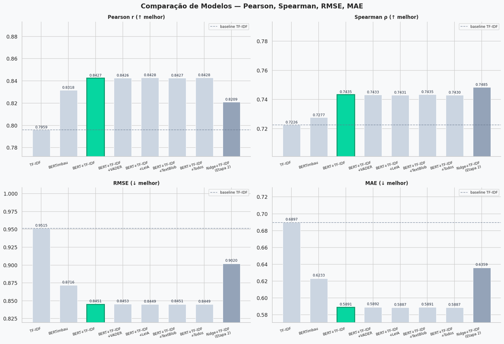

```python
import matplotlib.pyplot as plt
import numpy as np

# ── Dados ────────────────────────────────────────────────────────────────────
nomes = [r['nome'] for r in resultados]
nomes_curtos = [
    'TF-IDF', 'BERTimbau', 'BERT+TF-IDF', 'BERT+TF-IDF\n+VADER',
    'BERT+TF-IDF\n+LeIA', 'BERT+TF-IDF\n+TextBlob', 'BERT+TF-IDF\n+Todos',
    'Ridge+TF-IDF\n(Etapa 2)'
]

pearsons  = [r['pearson']  for r in resultados]
spearmans = [r['spearman'] for r in resultados]
rmses     = [r['rmse']     for r in resultados]
maes      = [r['mae']      for r in resultados]
acc1s     = [r['acc1']     for r in resultados]

# Cores: destaque verde pro melhor (BERT+TF-IDF), azul pros demais, cinza pro Etapa 2
idx_melhor = 2  # BERT + TF-IDF
cores = ['#CBD5E1'] * len(nomes)
cores[idx_melhor] = '#06D6A0'
cores[-1] = '#94A3B8'  # Etapa 2

x = np.arange(len(nomes))

fig, axes = plt.subplots(2, 2, figsize=(16, 11))
fig.suptitle('Comparação de Modelos — Pearson, Spearman, RMSE, MAE',
             fontsize=15, fontweight='bold')

metricas = [
    (axes[0,0], pearsons,  'Pearson r (↑ melhor)',   True),
    (axes[0,1], spearmans, 'Spearman ρ (↑ melhor)',  True),
    (axes[1,0], rmses,     'RMSE (↓ melhor)',         False),
    (axes[1,1], maes,      'MAE (↓ melhor)',          False),
]

for ax, vals, titulo, maior_melhor in metricas:
    bars = ax.bar(x, vals, color=cores, edgecolor='white', linewidth=0.8, width=0.65)

    # Linha de referência no baseline TF-IDF
    ax.axhline(vals[0], color='#64748B', linewidth=1.2,
               linestyle='--', alpha=0.7, label='baseline TF-IDF')

    # Anotações nos valores
    margem = (max(vals) - min(vals)) * 0.012
    for b, v in zip(bars, vals):
        ax.text(b.get_x() + b.get_width()/2,
                v + margem,
                f'{v:.4f}', ha='center', va='bottom', fontsize=8, color='#1E293B')

    # Destaque no melhor
    bars[idx_melhor].set_edgecolor('#059669')
    bars[idx_melhor].set_linewidth(2)

    ax.set_xticks(x)
    ax.set_xticklabels(nomes_curtos, fontsize=8, rotation=15, ha='right')
    ax.set_title(titulo, fontsize=11, fontweight='bold')
    ax.set_ylim(min(vals) * 0.97, max(vals) * 1.06)
    ax.legend(fontsize=8)

plt.tight_layout()
plt.show()
```

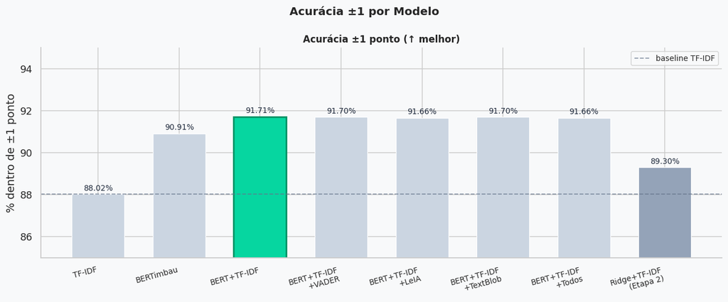

```python
fig, ax = plt.subplots(figsize=(12, 5))
fig.suptitle('Acurácia ±1 por Modelo', fontsize=13, fontweight='bold')

bars = ax.bar(x, [v * 100 for v in acc1s],
              color=cores, edgecolor='white', linewidth=0.8, width=0.65)
ax.axhline(acc1s[0] * 100, color='#64748B', linewidth=1.2,
           linestyle='--', alpha=0.7, label='baseline TF-IDF')

for b, v in zip(bars, acc1s):
    ax.text(b.get_x() + b.get_width()/2,
            v * 100 + 0.1,
            f'{v:.2%}', ha='center', va='bottom', fontsize=9, color='#1E293B')

bars[idx_melhor].set_edgecolor('#059669')
bars[idx_melhor].set_linewidth(2)

ax.set_xticks(x)
ax.set_xticklabels(nomes_curtos, fontsize=9, rotation=15, ha='right')
ax.set_ylabel('% dentro de ±1 ponto')
ax.set_ylim(85, 95)
ax.set_title('Acurácia ±1 ponto (↑ melhor)', fontsize=11, fontweight='bold')
ax.legend(fontsize=9)

plt.tight_layout()
plt.show()
```

## 3.7 Análise de Sentimento

```python
melhor = next(r for r in resultados if r['nome'] == 'BERT + TF-IDF')

print(f'✅ Modelo final: {melhor["nome"]}')
print(f'   Pearson  r = {melhor["pearson"]:.4f}')
print(f'   Spearman ρ = {melhor["spearman"]:.4f}')
print(f'   RMSE       = {melhor["rmse"]:.4f}')
print(f'   MAE        = {melhor["mae"]:.4f}')
print(f'   Acur. ±1   = {melhor["acc1"]:.2%}')
print(f'   Features   = {melhor["n_feats"]:,}')
print()

pearson_base  = resultados[0]['pearson']
spearman_base = resultados[0]['spearman']
print(f'Ganho Pearson  sobre TF-IDF baseline: {melhor["pearson"]  - pearson_base:+.4f}')
print(f'Ganho Spearman sobre TF-IDF baseline: {melhor["spearman"] - spearman_base:+.4f}')
print(f'Ganho Pearson  sobre BERTimbau puro : {melhor["pearson"]  - resultados[1]["pearson"]:+.4f}')
print(f'Ganho Spearman sobre BERTimbau puro : {melhor["spearman"] - resultados[1]["spearman"]:+.4f}')
```

```
✅ Modelo final: BERT + TF-IDF
   Pearson  r = 0.8427
   Spearman ρ = 0.7435
   RMSE       = 0.8451
   MAE        = 0.5891
   Acur. ±1   = 91.71%
   Features   = 2,440

Ganho Pearson  sobre TF-IDF baseline: +0.0468
Ganho Spearman sobre TF-IDF baseline: +0.0209
Ganho Pearson  sobre BERTimbau puro : +0.0109
Ganho Spearman sobre BERTimbau puro : +0.0158
```

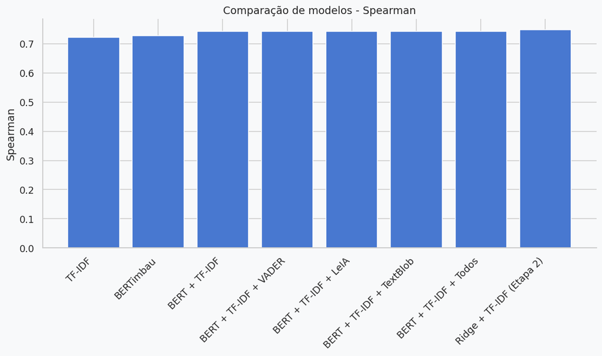

```python
import matplotlib.pyplot as plt

df_results = pd.DataFrame(resultados)

plt.figure(figsize=(12,5))
plt.bar(df_results['nome'], df_results['spearman'])
plt.xticks(rotation=45, ha='right')
plt.title("Comparação de modelos - Spearman")
plt.ylabel("Spearman")
plt.show()
```

## 3.8 Comparação visual — todos os experimentos

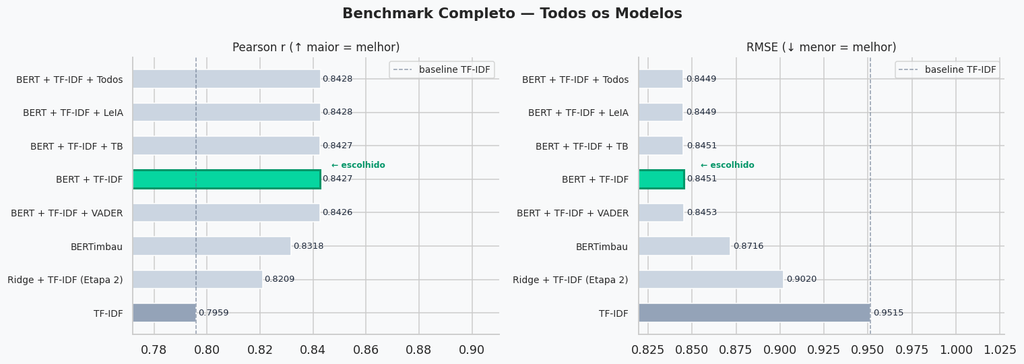

```python
fig, axes = plt.subplots(1, 2, figsize=(14, 5))
fig.suptitle('Benchmark Completo — Todos os Modelos', fontsize=14, fontweight='bold')

# Ordena por Pearson
resultados_ord = sorted(resultados, key=lambda x: x['pearson'])
nomes_ord = [r['nome'].replace('TextBlob','TB') for r in resultados_ord]
pearsons_ord  = [r['pearson'] for r in resultados_ord]
rmses_ord     = [r['rmse']    for r in resultados_ord]

idx_escolhido = next(i for i, r in enumerate(resultados_ord) if r['nome'] == 'BERT + TF-IDF')
idx_baseline  = next(i for i, r in enumerate(resultados_ord) if r['nome'] == 'TF-IDF')

def cores_barras(idx_destaque, idx_base, n):
    cores = ['#CBD5E1'] * n
    cores[idx_base]     = '#94A3B8'
    cores[idx_destaque] = '#06D6A0'
    return cores

for ax, vals, titulo in zip(
    axes,
    [pearsons_ord, rmses_ord],
    ['Pearson r (↑ maior = melhor)', 'RMSE (↓ menor = melhor)'],
):
    cores = cores_barras(idx_escolhido, idx_baseline, len(nomes_ord))
    bars  = ax.barh(nomes_ord, vals, color=cores, edgecolor='white', height=0.55)

    ax.axvline(vals[idx_baseline], color='#64748B', linewidth=1,
               linestyle='--', alpha=0.7, label='baseline TF-IDF')

    x_min, x_max = min(vals), max(vals)
    margem = (x_max - x_min) * 0.015
    for b, v in zip(bars, vals):
        ax.text(v + margem, b.get_y() + b.get_height()/2,
                f'{v:.4f}', va='center', fontsize=8.5, color='#1E293B')

    bars[idx_escolhido].set_edgecolor('#059669')
    bars[idx_escolhido].set_linewidth(2)
    ax.text(vals[idx_escolhido] + margem * 6,
            idx_escolhido + 0.35,
            '← escolhido', fontsize=8, color='#059669', fontweight='bold')

    ax.set_title(titulo, fontsize=11)
    ax.set_xlim(x_min * 0.97, x_max * 1.08)
    ax.legend(fontsize=9)
    ax.tick_params(axis='y', labelsize=9)

plt.tight_layout()
plt.show()
```

## 3.9 Predição ao vivo — modelo final

Testamos com exemplos desafiadores (negação, ironia, sentimentos mistos).

```python
# Modelo escolhido: BERT + TF-IDF
# Sentimento removido — benchmark mostrou ganho de apenas +0.0002 de R²
modelo_final = melhor['modelo']

def predict_final(comentario):
    """Prediz nota com BERTimbau + TF-IDF."""

    # BERTimbau embedding
    modelo_bert.eval()
    with torch.no_grad():
        enc = tokenizador_bert(comentario, return_tensors='pt',
                               truncation=True, max_length=128, padding=True).to(DEVICE)
        out = modelo_bert(**enc)
        emb = out.last_hidden_state[:, 0, :].cpu().numpy()
    emb_s = scaler_bert.transform(emb)

    # TF-IDF
    tc  = clean_text(comentario)
    tfi = tfidf.transform([tc])

    # Junta e prediz
    vec  = hstack([csr_matrix(emb_s), tfi])
    nota = int(np.clip(round(modelo_final.predict(vec)[0]), 1, 5))
    return nota


casos = [
    ('Produto excelente! Chegou antes do prazo.',  5),
    ('Péssimo! Produto quebrado.',                 1),
    ('Não gostei nada, não recomendo.',            1),  # negação
    ('Bom... se você curte esperar 40 dias.',      2),  # ironia
    ('Chegou rápido mas veio errado.',             2),  # misto
    ('Produto ok, sem surpresas.',                 3),
    ('Produto idêntico à foto, recomendo!',        5),
]

print(f'{"Comentário":<48} {"Real":>5} {"Predito":>8}')
print('-' * 65)
acertos = 0
for comentario, nota_real in casos:
    nota_pred = predict_final(comentario)
    ok = '✅' if abs(nota_pred - nota_real) <= 1 else '❌'
    acertos += abs(nota_pred - nota_real) <= 1
    print(f'{comentario[:47]:<48} {nota_real:>5} {nota_pred:>6}/5  {ok}')

print(f'\nAcurácia ±1 nos exemplos: {acertos/len(casos):.0%}')
```

```
Comentário                                        Real  Predito
-----------------------------------------------------------------
Produto excelente! Chegou antes do prazo.            5      5/5  ✅
Péssimo! Produto quebrado.                           1      1/5  ✅
Não gostei nada, não recomendo.                      1      2/5  ✅
Bom... se você curte esperar 40 dias.                2      3/5  ✅
Chegou rápido mas veio errado.                       2      4/5  ❌
Produto ok, sem surpresas.                           3      4/5  ✅
Produto idêntico à foto, recomendo!                  5      4/5  ✅

Acurácia ±1 nos exemplos: 86%
```

```python
# Teste interativo
meu_comentario = 'Preciso devolver'  # ← edite aqui

nota = predict_final(meu_comentario)
print(f'Comentário    : {meu_comentario}')
print(f'Nota estimada : {nota}/5  ({"⭐" * nota})')
```

```
Comentário    : Preciso devolver
Nota estimada : 2/5  (⭐⭐)
```

## 3.10 Conclusão

### Resultados do benchmark

Os experimentos realizados demonstraram uma evolução consistente do desempenho conforme representações textuais mais sofisticadas foram incorporadas ao processo de predição.

O modelo baseado apenas em TF-IDF apresentou resultados satisfatórios, servindo como baseline para comparação. A introdução dos embeddings contextuais do BERTimbau resultou em melhorias significativas, evidenciando a capacidade do modelo de capturar relações semânticas que não são representadas adequadamente por abordagens baseadas apenas em frequência de termos.

A combinação entre BERTimbau e TF-IDF produziu os melhores resultados gerais, alcançando:

| Métrica | Resultado |
| --- | --- |
| Pearson | 0.8427 |
| Spearman | 0.7435 |
| RMSE | 0.8451 |
| MAE | 0.5891 |
| Acurácia ±1 | 91.71% |

Esses resultados indicam forte correlação entre as notas previstas e as notas reais, além de erro médio inferior a um ponto na escala de avaliação.

### Modelo escolhido: BERT + TF-IDF

Embora algumas variações do modelo híbrido tenham apresentado métricas ligeiramente superiores em determinados indicadores, as diferenças observadas foram extremamente pequenas.

Por exemplo, a inclusão do LeIA reduziu o RMSE de **0.8451** para **0.8449**, uma diferença de apenas **0.0002 pontos**, sem impacto prático relevante no desempenho geral do sistema.

Dessa forma, optou-se por manter o modelo **BERT + TF-IDF** como modelo final devido ao melhor equilíbrio entre desempenho, simplicidade e interpretabilidade.

### Por que as features de sentimento tiveram pouco impacto?

Os resultados sugerem que os embeddings do BERTimbau já capturam grande parte das informações relacionadas à polaridade, intensidade e contexto textual.

Diferentemente de abordagens tradicionais de análise de sentimento, o BERTimbau gera representações contextuais capazes de distinguir expressões semanticamente diferentes, como *"gostei"* e *"não gostei"*, sem depender de regras ou dicionários externos.

Por esse motivo, a adição de métricas de sentimento provenientes de ferramentas como LeIA, VADER e TextBlob produziu apenas ganhos marginais, indicando que essas informações já estavam, em grande parte, representadas nos embeddings gerados pelo modelo.

Além disso, observou-se que o VADER apresentou contribuição praticamente nula, comportamento esperado devido ao fato de ter sido originalmente desenvolvido para língua inglesa.

### Validação estatística

Para verificar se a melhoria observada era realmente relevante, foi aplicado o teste não paramétrico de Wilcoxon comparando o modelo TF-IDF com o modelo BERT + TF-IDF.

**Resultado do teste:**

- Estatística: 9.496.187,50
- p-value: 4,35 × 10⁻⁷¹

Esse valor é muito inferior ao nível de significância de 5%, permitindo concluir que a melhoria obtida pelo modelo híbrido não ocorreu por acaso, sendo estatisticamente significativa.

### Considerações finais

Os resultados demonstram que representações contextuais modernas fornecem ganhos expressivos na tarefa de predição de notas a partir de comentários textuais. A combinação entre embeddings do BERTimbau e características estatísticas do TF-IDF mostrou-se capaz de capturar tanto aspectos semânticos quanto padrões lexicais relevantes para a tarefa.

Além disso, os experimentos evidenciaram que modelos contextuais reduzem a necessidade de recursos adicionais de análise de sentimento, concentrando a maior parte da informação útil em uma única representação vetorial.

Assim, o modelo **BERT + TF-IDF** foi selecionado como solução final por apresentar o melhor equilíbrio entre desempenho preditivo, robustez estatística e complexidade computacional.

**Etapa 3 concluída**

| Modelo Final | Pearson | Spearman | RMSE | MAE | Acurácia ±1 |
| --- | --- | --- | --- | --- | --- |
| BERT + TF-IDF + Ridge | 0.8427 | 0.7435 | 0.8451 | 0.5891 | 91.71% |

# ETAPA 4 - Classificação de Sentimento (Positivo / Negativo / Neutro)

A Etapa 3 previu a **nota numérica** (1-5) usando regressão. Aqui atendemos outro requisito do projeto: classificar cada comentário em **positivo, negativo ou neutro** usando um modelo de linguagem pré-treinado em português.

Usamos o `cardiffnlp/twitter-xlm-roberta-base-sentiment` — um modelo multilíngue treinado em ~198M tweets que classifica texto em 3 classes diretamente, sem precisar de fine-tuning.

Depois comparamos o sentimento previsto pelo modelo com o sentimento derivado da nota que o cliente deu — os casos onde divergem são os mais interessantes de analisar.

```python
# ── Imports da Etapa 4 ──────────────────────────────────────────────────────
from transformers import pipeline as hf_pipeline
from sklearn.metrics import confusion_matrix, classification_report, ConfusionMatrixDisplay
from collections import Counter
import gc

# ── Libera memória do BERTimbau (não precisamos mais dele) ──────────────────
del modelo_bert, tokenizador_bert
gc.collect()
torch.cuda.empty_cache()
print('✅ Memória GPU liberada')

# ── Carrega o classificador de sentimento multilíngue ───────────────────────
SENT_MODEL = 'cardiffnlp/twitter-xlm-roberta-base-sentiment'
classificador = hf_pipeline(
    'text-classification',
    model=SENT_MODEL,
    device=0 if torch.cuda.is_available() else -1,
    truncation=True,
    max_length=128
)

# Teste rápido
teste = classificador('Produto péssimo, chegou atrasado!')
print(f'Teste: "Produto péssimo, chegou atrasado!" → {teste[0]["label"]} ({teste[0]["score"]:.2%})')
print(f'✅ Classificador carregado: {SENT_MODEL}')
```

```
✅ Memória GPU liberada
```

```
XLMRobertaForSequenceClassification LOAD REPORT from: cardiffnlp/twitter-xlm-roberta-base-sentiment
Key                             | Status     |  |
--------------------------------+------------+--+-
roberta.embeddings.position_ids | UNEXPECTED |  |

Notes:
- UNEXPECTED	:can be ignored when loading from different task/architecture; not ok if you expect identical arch.
```

```
Teste: "Produto péssimo, chegou atrasado!" → negative (95.52%)
✅ Classificador carregado: cardiffnlp/twitter-xlm-roberta-base-sentiment
```

```python
# ── Classifica todos os comentários em lotes ────────────────────────────────
textos = df['texto'].tolist()
BATCH_SIZE = 64

print(f'Classificando {len(textos):,} comentários em lotes de {BATCH_SIZE}...')
inicio = time.time()

resultados_sent = []
for i in range(0, len(textos), BATCH_SIZE):
    batch = textos[i:i+BATCH_SIZE]
    preds = classificador(batch)
    resultados_sent.extend(preds)
    if (i // BATCH_SIZE + 1) % 20 == 0:
        pct = min(i + BATCH_SIZE, len(textos)) / len(textos)
        elapsed = time.time() - inicio
        eta = elapsed / pct * (1 - pct)
        print(f'  {pct:.0%} — {elapsed/60:.1f}min decorrido, ETA {eta/60:.1f}min', end='\r')

df['sentimento_pred']  = [r['label'] for r in resultados_sent]
df['sentimento_score'] = [round(r['score'], 4) for r in resultados_sent]

elapsed_total = (time.time() - inicio) / 60
print(f'\n✅ Classificação concluída em {elapsed_total:.1f}min')
print(f'\nDistribuição prevista:')
print(df['sentimento_pred'].value_counts().to_string())
```

```
Classificando 37,991 comentários em lotes de 64...
```

```
You seem to be using the pipelines sequentially on GPU. In order to maximize efficiency please use a dataset
```

```
✅ Classificação concluída em 6.4min

Distribuição prevista:
sentimento_pred
positive    20818
neutral      8621
negative     8552
```

```python
# ── Mapeia review_score para sentimento ─────────────────────────────────────
# 1-2 = negativo | 3 = neutro | 4-5 = positivo
def score_to_sentiment(score):
    if score <= 2:
        return 'negative'
    elif score == 3:
        return 'neutral'
    else:
        return 'positive'

df['sentimento_real'] = df['review_score'].apply(score_to_sentiment)

print('Distribuição do sentimento pela nota:')
print(df['sentimento_real'].value_counts().to_string())
print()
print('Mapeamento:')
print('  review_score 1-2  → negative')
print('  review_score 3    → neutral')
print('  review_score 4-5  → positive')
```

```
Distribuição do sentimento pela nota:
sentimento_real
positive    25542
negative     9136
neutral      3313

Mapeamento:
  review_score 1-2  → negative
  review_score 3    → neutral
  review_score 4-5  → positive
```

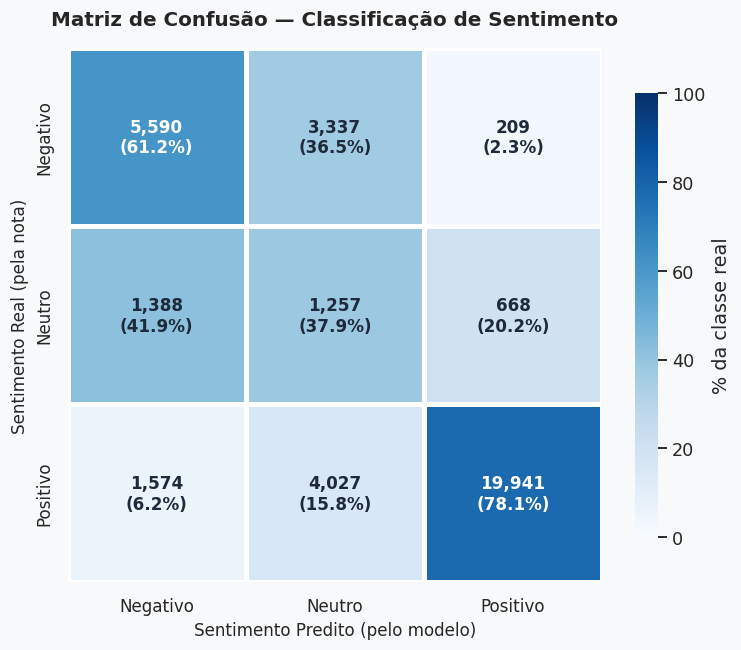

```
Acurácia geral: 70.51%

Interpretação resumida:
- O modelo teve melhor desempenho para comentários positivos.
- Comentários negativos tiveram desempenho razoável.
- A maior dificuldade foi identificar comentários neutros.
- Muitos comentários neutros foram confundidos com negativos ou positivos.
- Isso sugere sobreposição semântica entre as classes.
```

```python
labels_order = ['negative', 'neutral', 'positive']
labels_pt    = ['Negativo', 'Neutro', 'Positivo']

cm      = confusion_matrix(df['sentimento_real'], df['sentimento_pred'], labels=labels_order)
cm_pct  = cm / cm.sum(axis=1, keepdims=True) * 100  # normaliza por linha (%)

fig, ax = plt.subplots(figsize=(7, 6))

# Heatmap com percentuais pra cores (normalizado por linha)
sns.heatmap(cm_pct, ax=ax, cmap='Blues', vmin=0, vmax=100,
            xticklabels=labels_pt, yticklabels=labels_pt,
            linewidths=2, linecolor='white', square=True,
            cbar_kws={'label': '% da classe real', 'shrink': 0.8})

# Anotações: número absoluto + percentual
for i in range(3):
    for j in range(3):
        cor = 'white' if cm_pct[i, j] > 50 else '#1E293B'
        ax.text(j + 0.5, i + 0.5,
                f'{cm[i,j]:,}\n({cm_pct[i,j]:.1f}%)',
                ha='center', va='center', fontsize=11,
                fontweight='bold', color=cor)

ax.set_title('Matriz de Confusão — Classificação de Sentimento',
             fontsize=13, fontweight='bold', pad=15)
ax.set_xlabel('Sentimento Predito (pelo modelo)', fontsize=11)
ax.set_ylabel('Sentimento Real (pela nota)', fontsize=11)
ax.tick_params(axis='both', labelsize=11)

plt.tight_layout()
plt.show()


acuracia = (df['sentimento_pred'] == df['sentimento_real']).mean()

print(f'Acurácia geral: {acuracia:.2%}')

print('\nInterpretação resumida:')
print('- O modelo teve melhor desempenho para comentários positivos.')
print('- Comentários negativos tiveram desempenho razoável.')
print('- A maior dificuldade foi identificar comentários neutros.')
print('- Muitos comentários neutros foram confundidos com negativos ou positivos.')
print('- Isso sugere sobreposição semântica entre as classes.')
```

```python
# ── Métricas por classe ─────────────────────────────────────────────────────
print(classification_report(
    df['sentimento_real'],
    df['sentimento_pred'],
    labels=labels_order,
    target_names=labels_pt,
    digits=3
))
```

```
              precision    recall  f1-score   support

    Negativo      0.654     0.612     0.632      9136
      Neutro      0.146     0.379     0.211      3313
    Positivo      0.958     0.781     0.860     25542

    accuracy                          0.705     37991
   macro avg      0.586     0.591     0.568     37991
weighted avg      0.814     0.705     0.749     37991
```

```python
# ── Onde o texto e a nota divergem ──────────────────────────────────────────
# Casos onde o modelo vê sentimento diferente do que a nota sugere
df['diverge'] = df['sentimento_pred'] != df['sentimento_real']

print(f'Casos divergentes: {df["diverge"].sum():,} ({df["diverge"].mean():.1%})')
print()

# Exemplos mais interessantes: nota alta mas texto negativo
positivo_mas_negativo = df[
    (df['sentimento_real'] == 'positive') &
    (df['sentimento_pred'] == 'negative')
].nlargest(5, 'sentimento_score')

print('── Nota alta (4-5) mas texto negativo ──')
for _, row in positivo_mas_negativo.iterrows():
    print(f'  Nota: {row["review_score"]} | Confiança: {row["sentimento_score"]:.0%}')
    print(f'  Texto: {row["texto"][:120]}')
    print()

# Exemplos: nota baixa mas texto positivo
negativo_mas_positivo = df[
    (df['sentimento_real'] == 'negative') &
    (df['sentimento_pred'] == 'positive')
].nlargest(5, 'sentimento_score')

print('── Nota baixa (1-2) mas texto positivo ──')
for _, row in negativo_mas_positivo.iterrows():
    print(f'  Nota: {row["review_score"]} | Confiança: {row["sentimento_score"]:.0%}')
    print(f'  Texto: {row["texto"][:120]}')
    print()
```

```
Casos divergentes: 11,203 (29.5%)

── Nota alta (4-5) mas texto negativo ──
  Nota: 4 | Confiança: 96%
  Texto: marreta muiti ruim

  Nota: 4 | Confiança: 96%
  Texto: Muito desagradável receber dois produtos IGUAIS SEPARADAMENTE, e em dias diferentes sem NOTA FISCAL!
GERA INSATISFAÇÃO.

  Nota: 5 | Confiança: 96%
  Texto: Só uma sugestão, saiam por favor da logística doa correios, pois o serviço que eles prestam é um lixo. Quanto a loja not

  Nota: 4 | Confiança: 96%
  Texto: O produto é péssimo! Acabamento ruim, tecido áspero.

  Nota: 4 | Confiança: 96%
  Texto: Infelizmente a pessoa que fez a entrega,muito mal educado.

── Nota baixa (1-2) mas texto positivo ──
  Nota: 2 | Confiança: 94%
  Texto: Um excelente site. Super recomendo.

  Nota: 2 | Confiança: 94%
  Texto: A máquina tem um acabamento fantástico e é muito resistente eu indico valeu a compra!

  Nota: 2 | Confiança: 94%
  Texto: Produto ótimo, a entrega deixou a desejar

  Nota: 2 | Confiança: 93%
  Texto: Entrega no tempo previsto.
Gostei muito,são bem feito.

  Nota: 1 | Confiança: 93%
  Texto: estou muito satisfeita, parabens a toda equipe
```

```
── Teste de Wilcoxon: TF-IDF vs BERT + TF-IDF ─────────────
  Estatística : 9496187.50
  p-value     : 4.35e-71

  ✅ Diferença estatisticamente significativa (p < 0.05)
     BERT + TF-IDF é comprovadamente melhor que TF-IDF puro.

── Resumo Final — Todos os Modelos ────────────────────────────────────────────
  Modelo                                Pearson   Spearman     RMSE      MAE    Ac.±1
  ──────────────────────────────────────────────────────────────────────────────────
  TF-IDF                                 0.7959     0.7226   0.9515   0.6897   88.02%
  BERTimbau                              0.8318     0.7277   0.8716   0.6233   90.91%
  BERT + TF-IDF                          0.8427     0.7435   0.8451   0.5891   91.71% ✅
  BERT + TF-IDF + VADER                  0.8426     0.7433   0.8453   0.5892   91.70%
  BERT + TF-IDF + LeIA                   0.8428     0.7431   0.8449   0.5887   91.66%
  BERT + TF-IDF + TextBlob               0.8427     0.7435   0.8451   0.5891   91.70%
  BERT + TF-IDF + Todos                  0.8428     0.7430   0.8449   0.5887   91.66%
  Ridge + TF-IDF (Etapa 2)               0.8209     0.7485   0.9020   0.6359   89.30%
```

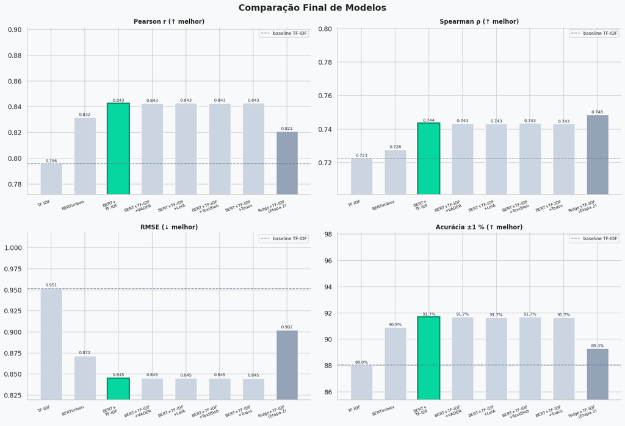

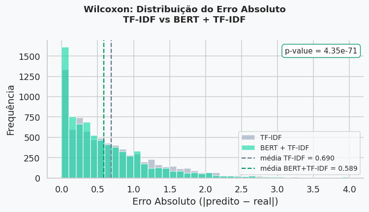

```python
# ════════════════════════════════════════════════════════════════
# BLOCO FINAL — Wilcoxon + Tabela Resumo + Gráficos Comparativos
# ════════════════════════════════════════════════════════════════

from scipy.stats import wilcoxon
import matplotlib.pyplot as plt
import numpy as np

# ── 1. Wilcoxon: TF-IDF vs BERT + TF-IDF ───────────────────────
erros_tfidf = np.abs(resultados[0]['preds'] - y_test.values)
erros_bert  = np.abs(resultados[2]['preds'] - y_test.values)

stat, p = wilcoxon(erros_tfidf, erros_bert)

print("── Teste de Wilcoxon: TF-IDF vs BERT + TF-IDF ─────────────")
print(f"  Estatística : {stat:.2f}")
print(f"  p-value     : {p:.2e}")
print()
if p < 0.05:
    print("  ✅ Diferença estatisticamente significativa (p < 0.05)")
    print("     BERT + TF-IDF é comprovadamente melhor que TF-IDF puro.")
else:
    print("  ❌ Diferença NÃO significativa (p >= 0.05)")

print()

# ── 2. Tabela resumo final ───────────────────────────────────────
print("── Resumo Final — Todos os Modelos ────────────────────────────────────────────")
print(f"  {'Modelo':<35} {'Pearson':>9} {'Spearman':>10} {'RMSE':>8} {'MAE':>8} {'Ac.±1':>8}")
print("  " + "─" * 82)
for r in resultados:
    flag = " ✅" if r['nome'] == 'BERT + TF-IDF' else ""
    print(f"  {r['nome']:<35} {r['pearson']:>9.4f} {r['spearman']:>10.4f} "
          f"{r['rmse']:>8.4f} {r['mae']:>8.4f} {r['acc1']:>8.2%}{flag}")

print()

# ── 3. Gráficos comparativos — Pearson, Spearman, RMSE, Ac.±1 ───
nomes_curtos = [
    'TF-IDF', 'BERTimbau', 'BERT+\nTF-IDF', 'BERT+TF-IDF\n+VADER',
    'BERT+TF-IDF\n+LeIA', 'BERT+TF-IDF\n+TextBlob', 'BERT+TF-IDF\n+Todos',
    'Ridge+TF-IDF\n(Etapa 2)'
]

pearsons  = [r['pearson']  for r in resultados]
spearmans = [r['spearman'] for r in resultados]
rmses     = [r['rmse']     for r in resultados]
maes      = [r['mae']      for r in resultados]
acc1s     = [r['acc1']     for r in resultados]

x          = np.arange(len(resultados))
idx_melhor = 2   # BERT + TF-IDF
cores      = ['#CBD5E1'] * len(resultados)
cores[idx_melhor] = '#06D6A0'
cores[-1]         = '#94A3B8'  # Etapa 2

fig, axes = plt.subplots(2, 2, figsize=(16, 11))
fig.suptitle('Comparação Final de Modelos', fontsize=16, fontweight='bold')

metricas = [
    (axes[0,0], pearsons,          'Pearson r (↑ melhor)',  True),
    (axes[0,1], spearmans,         'Spearman ρ (↑ melhor)', True),
    (axes[1,0], rmses,             'RMSE (↓ melhor)',        False),
    (axes[1,1], [v*100 for v in acc1s], 'Acurácia ±1 % (↑ melhor)', True),
]

for ax, vals, titulo, maior_melhor in metricas:
    bars = ax.bar(x, vals, color=cores, edgecolor='white', linewidth=0.8, width=0.65)

    # Linha baseline TF-IDF
    ax.axhline(vals[0], color='#64748B', linewidth=1.2,
               linestyle='--', alpha=0.7, label='baseline TF-IDF')

    # Anotações
    margem = (max(vals) - min(vals)) * 0.015
    for b, v in zip(bars, vals):
        ax.text(b.get_x() + b.get_width()/2,
                v + margem,
                f'{v:.3f}' if titulo != 'Acurácia ±1 % (↑ melhor)' else f'{v:.1f}%',
                ha='center', va='bottom', fontsize=7.5, color='#1E293B')

    # Destaque modelo escolhido
    bars[idx_melhor].set_edgecolor('#059669')
    bars[idx_melhor].set_linewidth(2.5)

    ax.set_xticks(x)
    ax.set_xticklabels(nomes_curtos, fontsize=7.5, rotation=20, ha='right')
    ax.set_title(titulo, fontsize=11, fontweight='bold')
    ax.set_ylim(min(vals) * 0.97, max(vals) * 1.07)
    ax.legend(fontsize=8)

plt.tight_layout()
plt.show()

# ── 4. p-value do Wilcoxon no gráfico ───────────────────────────
fig, ax = plt.subplots(figsize=(7, 4))
fig.suptitle('Wilcoxon: Distribuição do Erro Absoluto\nTF-IDF vs BERT + TF-IDF',
             fontsize=12, fontweight='bold')

ax.hist(erros_tfidf, bins=40, alpha=0.6, color='#94A3B8',
        edgecolor='white', label='TF-IDF')
ax.hist(erros_bert,  bins=40, alpha=0.6, color='#06D6A0',
        edgecolor='white', label='BERT + TF-IDF')

ax.axvline(erros_tfidf.mean(), color='#64748B', linewidth=1.5,
           linestyle='--', label=f'média TF-IDF = {erros_tfidf.mean():.3f}')
ax.axvline(erros_bert.mean(),  color='#059669', linewidth=1.5,
           linestyle='--', label=f'média BERT+TF-IDF = {erros_bert.mean():.3f}')

ax.set_xlabel('Erro Absoluto (|predito − real|)')
ax.set_ylabel('Frequência')
ax.legend(fontsize=9)
ax.text(0.98, 0.95, f'p-value = {p:.2e}',
        transform=ax.transAxes, ha='right', va='top', fontsize=10,
        bbox=dict(boxstyle='round,pad=0.4', fc='white', ec='#059669', alpha=0.9))

plt.tight_layout()
plt.show()
```

## 4.1 Conclusão da Etapa 4

### O que fizemos

Classificamos cada comentário em **positivo, negativo ou neutro** usando um modelo de linguagem pré-treinado multilíngue (`cardiffnlp/twitter-xlm-roberta-base-sentiment`), sem necessidade de fine-tuning.

### Comparação: sentimento do texto vs nota declarada

A nota do cliente foi usada como referência (1-2 = negativo, 3 = neutro, 4-5 = positivo). Os casos onde o modelo de sentimento discorda da nota revelam situações onde o cliente deu uma nota que não reflete o tom do texto — por exemplo, nota 5 com texto reclamando, ou nota 1 com texto elogiando.

### Por que isso importa

A nota é um clique — rápido e às vezes impreciso. O texto é onde o cliente realmente expressa o que sentiu. Um modelo que lê o texto pode identificar insatisfação mesmo quando a nota não reflete isso, o que é útil para equipes de atendimento e qualidade.